# Notas de Aula de Estatistica Bayesiana

Lia Hanna Martins Morita

2020

**Materiais de apoio**  
(abrir em uma nova janela do navegador)  
contato por email: profaliaufmt@gmail.com ou através do AVA UFMT

[Guia de Estudos](https://github.com/liamorita/estatisticabayesiana/blob/master/guia_bayes.pdf)

[Apostila da disciplina em pdf](https://github.com/liamorita/estatisticabayesiana/blob/master/main_file.pdf)

[Apostila da disciplina em html](https://github.com/liamorita/estatisticabayesiana/blob/master/main_file.html)

[Tábua de distribuições](https://github.com/liamorita/estatisticabayesiana/blob/master/Tabua%20de%20distribuicoes%20de%20probabilidade.pdf)

[Atividades síncronas no google meet (dia & horários no Guia de Estudos)](https://meet.google.com/qae-jcyo-zdq)

# Referências na literatura

- BERNARDO, J. M., SMITH, A. F. M.. Bayesian theory. New York: John Wiley & Sons. 1994;
- BERRY, D.A. Statistics: A Bayesian Perspective. Duxbury Press, Belmont, 1996
- BOX, G.E.P.; TIAO, G.C. Bayesian inference in statistical analysis. New York: J. Wiley, 1973. 360p.
- CASELLA, G.; BERGER, R. L. Inferência estatísitca. São Paulo: Cengage Learning, c2011. xi, 588 p.
- DEGROOT, M. H. & SCHERVISH, M. J. Probability and Statistics. New York: Addison Wesley, 2002.
- GELMAN, A., CARLIN, J.B., STERN, H.S., RUBIN, D.B. Bayesian data analysis. 2. ed. London: Chapman and Hall, 2004.
- KINAS, P.G., ANDRADE, H.A. Introdução à análise Bayesiana (com R). Porto Alegre: MaisQnada 2010
- LEE, P.M. Bayesian Statistics: an Introduction. 2. ed. New York: Edward Arnold, 1996
- PAULINO, C. D.; TURKMAN, M. A. A.; MURTEIRA, B.. Estatistica bayesiana. Fundacao Calouste Gulbenkian 2003 ed. 446 p.

# 1 UNIDADE I – Medição de Incertezas

Os métodos Bayesianos têm aplicação em muitas áreas como epidemiologia, bioestatística, engenharia, ciência da computação, entre outros.

## 1.1 Teoria das probabilidades e axiomas

**Definição 1.1: Partição de um Espaço Amostral** Dizemos que os eventos $A_1,A_2,\ldots,A_n$ formam uma partição do espaço amostral $\Omega$ se as seguintes propriedades são satisfeitas:

- $A_i\neq\emptyset,i=1,\ldots,n$: significa que nenhum evento pode ser igual ao conjunto vazio;
- $A_i$ $\cap$ $A_j$ = $\emptyset$, para $i$ $\neq$ $j$: significa que os eventos são disjuntos;
- $\cup^{n}_{i=1}A_i=\Omega$: significa que a união (ou reunião) de todos os eventos totaliza o espaço amostral.

Figura 1: Representação gráfica de partição de um espaço amostral.

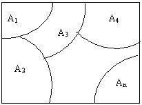

**Definição 1.2: Classe de eventos do espaço amostral** A classe de eventos do espaço amostral $\Omega$, também chamada de *classe de subconjuntos do espaço amostral $\Omega$*, ou *Conjunto das partes de $\Omega$*, é o conjunto que contém todos os subconjuntos de $\Omega$ e é representado por $\mathcal{P}(\Omega)$.

**Conceito de probabilidade** A probabilidade é definida numa classe de eventos do espaço amostral, com certas propriedades.

**Definição 1.3:** Probabilidade é uma função $P(.)$ que associa a cada evento de $\mathcal{P}(\Omega)$ (ou subconjunto de $\Omega$) um número real pertencente ao intervalo $[0,1]$, satisfazendo aos Axiomas de Kolmogorov

- Axioma 1: $P(A) \geq 0$ para todo evento $A$, $A \subset \Omega$: significa que a probabilidade é sempre um número real não negativo;
- Axioma 2: $P(\Omega)=1$: significa que $\Omega$ é um evento certo pois reúne todas as possibilidades;
- Axioma 3: $P(\cup^{\infty}_{i=1}A_i)=\sum_{i=1}^{\infty}P(A_{i})$, se $A_1, A_2, \ldots$ forem, dois a dois, mutuamente exclusivos:

significa que a probabilidade da união de dois ou mais eventos é igual à soma de suas respectivas probabilidades, se os eventos forem mutuamente exclusivos aos pares.

**Teorema 1.4:** Se os eventos $A_1, A_2, \ldots, A_n$ formam uma partição do espaço amostral, então:
$$\sum_{i=1}^n P(A_{i})=1.$$

**Demonstração:** A demonstração vem da definição de partição e dos Axiomas 2 e 3 de Kolmogorov.

**Definição 1.5: Probabilidade condicional** A probabilidade condicional de $B$ dado $A$ é dada pela fórmula:
$$P(B|A) = \frac{P(A \cap B)}{P(A)},$$
sendo que $P(A)$ deve ser maior do que zero.

**Teorema 1.6:Teorema do produto**
$$P(A \cap B) = P(A) P(B|A) \text{ e também } P(A \cap B) = P(B) P(A|B).$$

**Demonstração:** A demonstração vem da definição de probabilidade condicional.

**Proposição 1.7: Generalização do Teorema do Produto** Sejam $A_1$, $A_2$,$\ldots$, $A_{n-1}$, $A_n$ eventos do espaço amostral $\Omega$, onde está definida a probabilidade $P$, temos:
$$P(A_1\cap A_2 \ldots \cap A_{n-1}\cap A_n) = P(A_1)P(A_2|A_1)P(A_3|A_1\cap A_2)P(A_n|A1\cap A2 \ldots A_{n-1}).$$
**Demonstração**: A demonstração é através do Princípio da Indução Finita.

**Teorema 1.8: Teorema da Probabilidade Total** (ou Fórmula da Probabilidade Total): Sejam $A_1,A_2,\ldots,A_n$ eventos que formam uma partição do espaço amostral. Seja $B$ um evento deste espaço.
$$P(B) = \sum_{i=1}^n P(A_i)P(B|A_i),$$
onde $A_1, A_2, \ldots A_n$ formam uma partição no espaço amostral.

A fórmula da Probabilidade Total permite calcular a probabilidade de um evento $B$ a partir das probabilidades de um conjunto de eventos disjuntos cuja reunião é o espaço amostral; e as probabilidades condicionais de $B$ dado cada um destes eventos são fornecidas.

**Demonstração** - Passo 1: Como $A_1, \ldots, A_n$ formam uma partição, então podemos escrever $B$ da seguinte forma:
$$B = (B \cap A_1) \cup (B \cap A_2) \cup (B \cap A_3) \cup \ldots \cup (B \cap A_n).$$

Figura 2: Representação gráfica do teorema da probabilidade total.

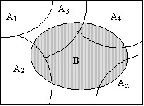

- Passo 2: Como $A_1,A_2,\ldots,A_n$ são disjuntos, então pelo **axioma 3 de Kolmogorov**, temos:
  $$P(B) = P(B \cap A_1) + P(B \cap A_2) + P(B \cap A_3) \ldots + P(B \cap A_n).$$
- Passo 3: Utilizando o Teorema do Produto, podemos escrever:
  $$P(B) = P(A_1)P(B|A_1)+ P(A_2)P(B|A_2)+P(A_3)P(B|A_3)+ \ldots +P(A_n)P(B|A_n).$$

**Teorema 1.9: Teorema de Bayes (ou fórmula de Bayes):**

$$P(A | B) = \frac{P(B|A) P(A)}{P(B)}.$$

**Demonstração:** A demonstração vem da Definição de probabilidade condicional, Teorema do Produto e Teorema da Probabilidade Total.

**Teorema de Bayes - Caso geral**
$$P(A_i|B)=\frac{P(A_i)P(B|A_i)}{\sum_{i=1}^n P(A_i)P(B|A_i)},$$

onde $A_1, A_2, \ldots A_n$ formam uma partição no espaço amostral

## 1.2 Exercícios

- 1. Um novo teste para detectar o vírus HIV apresenta $95\%$ de sensitividade e $98\%$ de especificidade. Numa população com uma prevalência de $0,1\%$ para a doença
  - 1. qual é a probabilidade de um indivíduo com teste positivo ter o vírus HIV?
  - 2. qual é a probabilidade de um indívíduo com teste negativo não ter o vírus HIV?
  - 3. Utilize o resultado dos itens $a)$ e $b)$ para responder à seguinte pergunta: Por que quando o teste dá resultado positivo o laboratório repete o teste, mas do contrário não é necessário repetir o teste?

**Ajuda:** sensibilidade do teste: é a probabilidade do teste dar resultado positivo para um indivíduo que tem a doença, especificidade do teste: é a probabilidade do teste dar resultado negativo para um indivíduo que não tem doença, prevalência: é a proporção de pessoas com a doença em certa população de interesse. Em testes diagnósticos, temos interesse em encontrar o teste que possui os maiores valores de sensibilidade e especificidade.

- 2. Em um determinado posto de gasolina, 40% dos clientes usam gasolina comum, 35% usam gasolina aditivada e 25% usam gasolina Premium. Dos clientes que usam gasolina comum apenas 30% enchem o tanque; dentre os que usam gasolina aditivada 60% enchem o tanque; e dentre os que usam Premium 50% enchem o tanque.
  - 1. Qual é a probabilidade de um cliente encher o tanque, sabendo-se que ele pediu gasolina comum?
  - 2. Qual é a probabilidade de um cliente pedir gasolina aditivada e encher o tanque?
  - 3. Qual é a probabilidade de um cliente encher o tanque?
  - 4. Dado que o cliente encheu o tanque, qual é a probabilidade dele ter pedido gasolina comum? E gasolina aditivada? E gasolina Premium?
- 3. Uma máquina produz $5\%$ de itens defeituosos. Cada item produzido passa por um teste de qualidade que o classifica como bom, defeituoso ou suspeito. Este teste classifica $20\%$ dos itens defeituosos como bons e $30\%$ como suspeitos. Ele também classifica $15\%$ dos itens bons como defeituosos e $25\%$ como suspeitos. Utilize o Teorema de Bayes para responder às perguntas abaixo:
  - 1. Que proporção dos itens serão classificados como suspeitos?
  - 2. Qual a probabilidade de um item classificado como suspeito ser defeituoso?

## 1.3 Componentes da inferência Bayesiana

- Distribuição *a priori* : utiliza a probabilidade como um meio de quantificar a incerteza sobre quantidades desconhecidas (variáveis), então temos $f(\theta)$: distribuição *a priori* para o parâmetro $\theta$;
- Verossimilhança : relaciona todas as variáveis num modelo de probabilidade completo, então temos $L(\theta | \boldsymbol{y})$: função de verossimilhança de $\theta$ dado o conjunto de dados, vem diretametne de $f(\boldsymbol{y}|\theta)$:
- Distribuição *a posteriori* : quando observamos algumas variáveis (os dados), podemos usar a fórmula de Bayes para encontrar as distribuições de probabilidade condicionais para as quantidades de interesse não observadas, então temos $f(\theta | \boldsymbol{y})$: distribuição *a posteriori* para o parâmetro $\theta$.

Nosso principal objetivo é utilizar a distribuição *a posteriori* para a nossa tomada de decisões. Pelo **Teorema de Bayes**, temos:

- 1. **Caso discreto:** neste caso, assumimos que $\theta$ é uma variável aleatória discreta.
     $$P(\theta=\theta_j|\boldsymbol{y})=\frac{P(\theta=\theta_j)f(\boldsymbol{y}|\theta)}{\sum \limits_j P(\theta=\theta_j) f(\boldsymbol{y}|\theta)},$$
     onde $\theta_j, j=1,2,\ldots$ são os valores que $\theta$ pode assumir, ou seja, **o espaço paramétrico de $\theta$ é discreto**,
- 2. **Caso contínuo:** neste caso, assumimos que $\theta$ é uma variável aleatória contínua.
     $$f(\theta|\boldsymbol{y})=\frac{f(\theta)f(\boldsymbol{y}|\theta)}{\int \limits_\Theta f(\theta)f(\boldsymbol{y}|\theta) d\theta},$$
     onde $\Theta$ é o espaço paramétrico de $\theta$, **o espaço paramétrico de $\theta$ é contínuo**

**Observações:**

- O caso contínuo é mais comumente utilizado na estatística Bayesiana,
- A distribuição *a priori* também pode ser denotada por $p(\theta)$ ou $\pi(\theta)$, assim como a distribuição *a posteriori* denotada por $p(\theta | \boldsymbol{y})$ ou $\pi(\theta | \boldsymbol{y})$,
- Em geral, não é necessário efetuar o cálculo do denominador $\int \limits_\Theta f(\theta)L(\theta | \boldsymbol{y}) d\theta$ pois se trata de uma constante que não depende de $\theta$, então temos
  $$f(\theta|\boldsymbol{y})\propto \frac{f(\theta)L(\theta | \boldsymbol{y})}{\int \limits_\Theta f(\theta)L(\theta | \boldsymbol{y}) d\theta},$$
  donde o símbolo $\propto$ significa “é proporcional a”,
- As distribuições *a priori* podem ser de vários tipos e características:
- Quanto à propriedade de integrabilidade: existem *prioris* **próprias** ou **impróprias**,
- Quanto ao nível de informação: existem *prioris* **não informativas** ou **informativas**,
- Quanto a depender ou não da amostra (dos dados): existem *prioris* **subjetivas** ou **objetivas**

### 1.3.1 Exercícios - continuação

- 4. Seja $Y$ uma variável aleatória com distribuição Binomial $Y \sim \text{ Binomial }(n,p)$.
  - 1. Qual é a estimativa de máxima verossimilhança de $p$?
  - 2. Se $p$ tem distribuição *a priori* Beta com parâmetros conhecidos $a$ e $b$ então qual é a distribuição *a posteriori* para $p$?
  - 3. Segundo o item $b)$, qual é a média *a posteriori* para $\theta$?

**Dicas para o item $b)$**
$$P(Y=y)=?$$
Qual é a distribuição de Y (os dados)? $f(p)=$? Qual é a distribuição *a priori* para o parâmetro $p$? $f(p|\boldsymbol{y})=$ ? Qual é a distribuição de $p$ condicionada aos dados?

- 5. Foram gerados $10$ valores da distribuição de Poisson com taxa $\lambda=2$, através do seguinte código no software R:

```r
set.seed(15052017)
lambda=2  #este é o valor verdadeiro de lambda
n=10
x=rpois(n,lambda)
x
```

```
##  [1] 3 2 0 1 4 4 3 0 3 3
```

- 1. Obtenha a estimativa de máxima verossimilhança para $p$;
- 2. Considerando a distribuição *a priori* Gamma com média $1$ e variância $5$, obtenha a distribuição *a posteriori* para $\lambda$;
- 3. Segundo o item $b)$, qual é a média *a posteriori* para $\lambda$?
- 4. Segundo o item $b)$, qual é a variância *a posteriori* para $\lambda$? Veremos mais tarde que os exercícios 4 e 5 envolvem distribuições *a priori* conjugadas.

**Resolução:** - Estimativa de máxima verossimilhança

```r
    lambda_hat=mean(x) #estimativa de maxima verossimilhança
    lambda_hat
```

```
## [1] 2.3
```

- Fazendo os graficos da priori, verossimilhança e posteriori

```r
    lambda=seq(0,5,0.1) #só assume valores positivos
```

- Priori

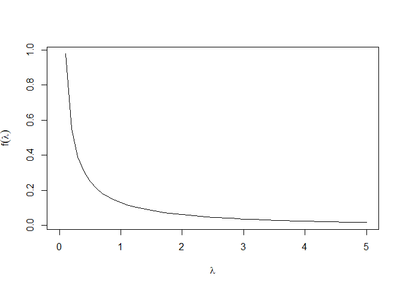

```r
priori_lambda=dgamma(lambda,shape=1/5, scale=5) #na parametrização do R, o parâmetro de   escala beta é invertido
plot(lambda,priori_lambda,type='l',xlab=expression(lambda),ylab=expression(f(lambda)))
```

- Verossimilhança

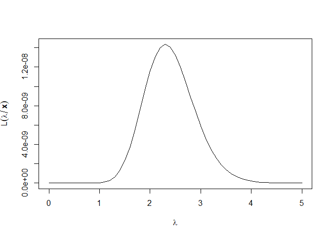

```r
    L_lambda=exp(-n*lambda)*lambda^(sum(x))*1/(prod(factorial(x)))
    plot(lambda,L_lambda,type='l',ylab=expression(L(lambda/bold(x))),xlab=expression(lambda))
```

- Posteriori

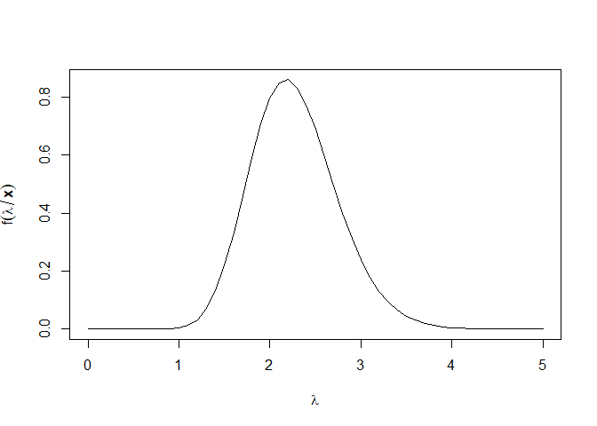

```r
posteriori_lambda=dgamma(lambda,shape=sum(x)+1/5, scale=1/(n+1/5)) #na parametrização do R, o parâmetro de escala beta é invertido
plot(lambda,posteriori_lambda,type='l',xlab=expression(lambda),ylab=expression(f(lambda/bold(x))))
```

# 2 UNIDADE II – Análise Bayesiana de Dados

## 2.1 Prioris conjugadas

Uma família de distribuições *a priori* é conjugada se as distribuições *a posteriori* pertencem a esta mesma família de distribuições.

### 2.1.1 Casos principais de *prioris* conjugadas

**Priori normal e verossimilhança normal (Caso 1)**

$\checkmark$ Temos uma amostra de tamanho $n$ i.i.d. com distribuição normal, com média $\mu$ e variância $\sigma^2$: $Y_i \sim N(\mu,\sigma^2), i=1,2,\ldots,n$:
$$f_{Y_i}(y_i)=\frac{1}{\sqrt{2 \pi} \sigma} \exp \left[-\frac{1}{2 \sigma^2} (y_i-\mu)^2 \right],$$
com $\mu$ desconhecido e $\sigma^2$ conhecido;

$\checkmark$ A função de verossimilhança será

$$\begin{eqnarray*}
L(\mu|\boldsymbol{y})&=&\prod \limits_{i=1}^n f_{Y_i}(y_i) \\
&=& \prod \limits_{i=1}^n \left\{ \frac{1}{\sqrt{2 \pi} \sigma} \exp \left[-\frac{1}{2 \sigma^2} (y_i-\mu)^2 \right]\right\}\\
&\propto& \exp \left[-\frac{1}{2 \sigma^2} \sum \limits_{i=1}^n (y_i-\mu)^2 \right],
\end{eqnarray*}$$

donde o símbolo $\propto$ significa “é proporcional a”, ou seja, todos os termos multiplicativos que não dependem de $\mu$ podem ser desconsiderados na fórmula.

A função de verossimilhança nos traz toda a informação disponível na amostra (nos dados).

$\checkmark$ A distribuição *a priori* para $\mu$ é normal: $\mu \sim N(m_0,s_0^2)$:
$$f(\mu)=\frac{1}{\sqrt{2 \pi} s_0} \exp \left[-\frac{1}{2 s_0^2} (\mu-m_0)^2 \right],$$
com $m_0$ e $s_0^2$ conhecidos. A distribuição *a priori* nos traz o conhecimento *a priori* sobre a média $\mu$.

- Se temos pouca informação a respeito de $\mu$, podemos fixar a média $m_0$ e atribuir uma variância $s_0^2$ grande;
- Se temos muita informação a respeito de $\mu$, podemos fixar a média $m_0$ e atribuir uma variância $s_0^2$ pequena. $\checkmark$ A distribuição *a posteriori* para $\mu$ será:

$$\begin{eqnarray*}
f(\mu | \boldsymbol{y}) &\propto& f(\mu ) . L(\mu|\boldsymbol{y})\\
&\propto& \exp \left[-\frac{1}{2} \left( \frac{1}{s_0^2} (\mu-m_0)^2 + \frac{1}{\sigma^2} \sum \limits_{i=1}^n (y_i-\mu)^2 \right) \right],
\end{eqnarray*}$$

donde temos:
$$\mu | \boldsymbol{y} \sim N\left(\frac{\frac{m_0}{s_0^2}+\frac{n \overline{y}}{\sigma^2}}{\frac{1}{s_0^2}+\frac{n}{\sigma^2}},\frac{1}{\frac{1}{s_0^2}+\frac{n}{\sigma^2}}\right)$$

**Demonstração** Veja demonstração em aula.

$\checkmark$ Então concluímos que dado um modelo normal com média desconhecida e variância conhecida, então a *priori* conjugada para a média é normal.

## 2.2 Prioris Conjugadas - continuação

**Exemplo 1** Box & Tiao (1973) Os físicos $A$ e $B$ desejam determinar uma constante física $\theta$. O físico $A$ tem mais experiência nesta área e especifica sua priori como $\theta \sim N(900,20^2)$. O físico $B$ tem pouca experiência e especifica uma priori muito mais incerta em relação à posição de $\theta$, $\theta \sim N(800,80^2)$. Assim, nós verificamos que:

- Para o físico $A$: $\displaystyle \quad P(860<\theta<940)\approx 0,95;$
- Para o físico $B$: $\displaystyle \quad P(640<\theta<960)\approx 0,95.$

Faz-se então uma medição $X$ de $\theta$ em laboratório com um aparelho calibrado com distribuição amostral $X \vert \theta \sim N(\theta,40^2)$ e observou-se $X=850$. Aplicando o “Caso 1)” de *prioris* conjugadas, temos:

- para o físico $A$: - a variância de $\theta$ era igual a $400$, e passou a ser igual a $320$ $\Rightarrow$ significa que ganhamos informação com os dados observados; - a **precisão** de $\theta$ passou de $0,0025$ para $0,00312$ (aumento de $25\%$ na precisão), - a **precisão** é usualmente representada pela letra grega $\tau$ e é igual ao inverso da variância;
- para o físico $B$: - a variância de $\theta$ era igual a $6400$, e passou a ser igual a $1280$; - precisão de $\theta$ passou de $0,000156$ para $0,000781$ (aumento de 400%).
- Abaixo temos a representação gráfica da distribuição *a priori*, verossimilhança e distribuição *a posteriori*.
- A distribuição *a posteriori* representa um compromisso entre a distribuição *a priori* e a verossimilhança. Além disso, como as incertezas iniciais são bem diferentes, o mesmo experimento fornece muito pouca informação adicional para o físico $A$ enquanto que a incerteza do físico $B$ foi bastante reduzida.

**Tarefa** Verifique o desenvolvimento em R para este exemplo.

```r
q1=qnorm(0.025,mean=900,sd=20)
q2=qnorm(0.975,mean=900,sd=20)
print(paste0("q1=",q1," & q2=",q2))
```

```
## [1] "q1=860.800720309199 & q2=939.199279690801"
```

```r
q1=qnorm(0.025,mean=800,sd=80)
q2=qnorm(0.975,mean=800,sd=80)
print(paste0("q1=",q1," & q2=",q2))
```

```
## [1] "q1=643.202881236796 & q2=956.797118763204"
```

- Gráficos das distribuições a priori - atribui valores no eixo para theta, para plotar no gráfico

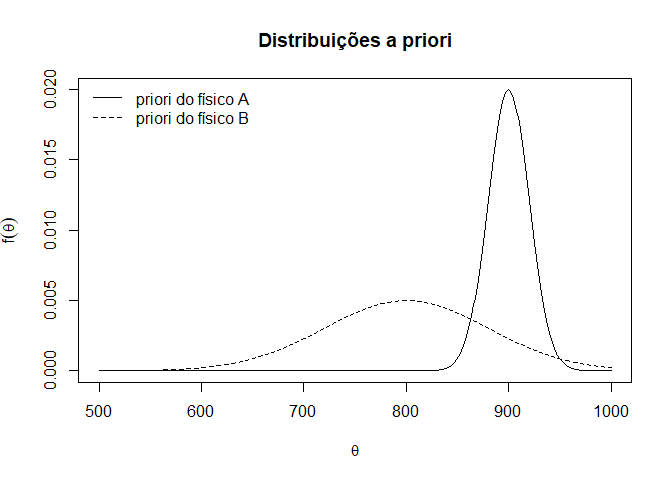

```r
theta=seq(500,1000)
priori_theta_A=dnorm(theta,mean=900,sd=20)
priori_theta_B=dnorm(theta,mean=800,sd=80)
plot(theta,priori_theta_A,type='l',xlab=expression(theta),ylab=expression(f(theta)),
main="Distribuições a priori")
lines(theta,priori_theta_B,type='l',lty=2)
legend("topleft",c("priori do físico A","priori do físico B"),lty=c(1,2),bty = "n")
```

- Gráfico da função de verossimilhança

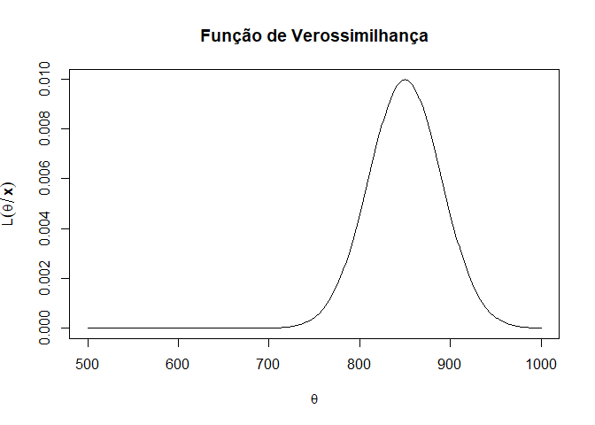

```r
x=850
L_theta=dnorm(x,mean=theta,sd=40)
plot(theta,L_theta,type='l',xlab=expression(theta),ylab=expression(L(theta/bold(x))),
main="Função de Verossimilhança")
```

- Gráfico das distribuições a posteriori. As distribuições à posteriori vêm do “Caso 1)” de prioris conjugadas

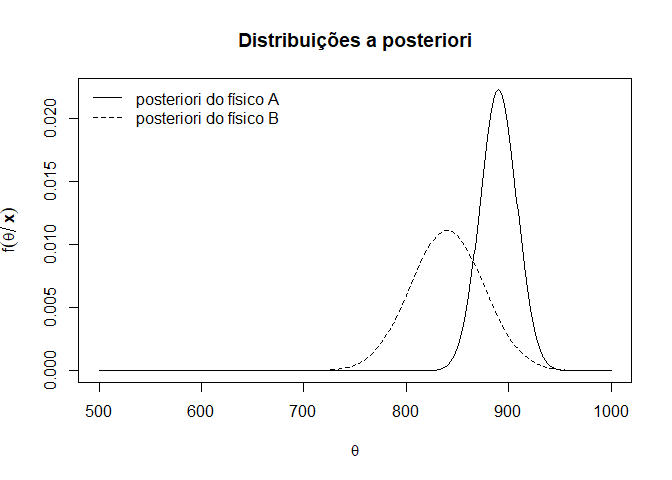

```r
n=1 #tamanho da amostra
y_bar=850 #é a média amostral dos dados
sigma2=1600 #é a variância dos dados (no caso 1 a variancia é conhecida)
posteriori=function(m_0,sigma2_0){ #m_0 é a média a priori e sigma2_0 é a variância a priori
#(varia para os físicos A e B)
media=(m_0/sigma2_0+n*y_bar/sigma2)/(1/sigma2_0+n/sigma2)
#onde m_0 é a média a priori e sigma2_0 é a variância a priori (varia para os físicos A e B)
variancia=1/(1/sigma2_0+n/sigma2)
dnorm(theta,mean=media,sd=sqrt(variancia))
}
plot(theta,posteriori(900,20^2),type='l',xlab=expression(theta),ylab=expression(f(theta/bold(x))),main="Distribuições a posteriori")
lines(theta,posteriori(800,80^2),type='l',lty=2)
legend("topleft",c("posteriori do físico A","posteriori do físico B"),lty=c(1,2),bty = "n")
```

- Gráficos das três funções conjuntamente: priori, verossimilhança e posteriori. - cria uma janela para dois gráficos (1 linha por 2 colunas)

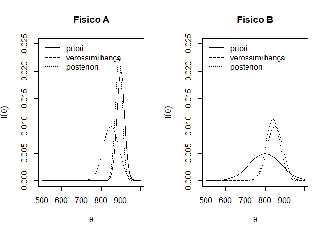

```r
par(mfrow=c(1,2))

#Para o físico A
plot(theta,priori_theta_A,type='l',xlab=expression(theta),ylab=expression(f(theta)),
main="Fisico A",ylim=c(0,0.025))
lines(theta,L_theta,type='l',lty=2)
lines(theta,posteriori(900,20^2),type='l',lty=3)
legend("topleft",c("priori","verossimilhança","posteriori"),lty=c(1,2,3),bty = "n")

#Para o físico B
plot(theta,priori_theta_B,type='l',xlab=expression(theta),ylab=expression(f(theta)),
main="Fisico B",ylim=c(0,0.025))
lines(theta,L_theta,type='l',lty=2)
lines(theta,posteriori(800,80^2),type='l',lty=3)
legend("topleft",c("priori","verossimilhança","posteriori"),lty=c(1,2,3),bty = "n")
```

### 2.2.1 Distribuição de Poisson($\lambda$) com *priori* gamma para a taxa $\lambda$ (Caso 2)

(Caso 2) - Temos uma amostra de tamanho $n$ i.i.d. com distribuição **Poisson** com taxa $\lambda$: $Y_i \sim \text{Poisson}(\lambda), i=1,2,\ldots,n$:
$$P(Y_i=y_i)=\frac{\exp(-\lambda) \lambda^{y_i}}{y_i!},$$
com $\lambda$ desconhecido;

- A função de verossimilhança será

$$\begin{eqnarray*}
L(\lambda|\boldsymbol{y})&=&\prod \limits_{i=1}^n P(Y_i=y_i) \\
&=& \prod \limits_{i=1}^n \frac{\exp(-\lambda) \lambda^{y_i}}{y_i!} \\
&\propto& \exp (-n \lambda) \lambda^{\sum \limits_{i=1}^n y_i},
\end{eqnarray*}$$

em que todos os termos multiplicativos que não dependem de $\lambda$ foram desconsiderados na fórmula.

$L(\lambda|\boldsymbol{y})$ é uma função de $\lambda$ (nosso parâmetro desconhecido).

- Na **inferência clássica**, nós procedemos com o método usual de maximizar $\log \left(L(\lambda|\boldsymbol{y})\right)$ com respeito a $\lambda$, pois estamos tratando de um **parâmetro fixo e desconhecido**;
- Na **inferência Bayesiana**, ao invés de encontrar a **estimativa de máxima verossimilhança**, nós estamos interessados na distribuição *a posteriori*, pois estamos tratando de um **parâmetro desconhecido** cuja distribuição *a priori* é a nossa crença *a priori* antes de observar os dados.
- A distribuição *a priori* para $\lambda$ é **Gamma**: $\lambda \sim \text{Gamma} (\alpha,\beta)$,
  $$f(\lambda)=\frac{\beta^\alpha}{\Gamma[\alpha]} \lambda^{\alpha-1} \exp(-\beta \lambda),$$
  $\text{ com } \alpha>0 \text{ e } \beta>0$ parâmetros conhecidos.
- A distribuição *a posteriori* para $\lambda$ será:

$$\begin{eqnarray*}
f(\lambda | \boldsymbol{y}) &\propto& \exp \left(- \lambda (n + \beta ) \right) \lambda ^{\sum \limits_{i=1}^n y_i + \alpha - 1} \end{eqnarray*}$$
donde temos:

$$\lambda | \boldsymbol{y} \sim \text{Gamma} \left(\sum \limits_{i=1}^n y_i + \alpha,n + \beta\right)$$

## 2.3 Distribuição de Binomial($\theta$) com *priori* beta para a proporção $\theta$ (Caso 3)

Demonstração em aula

## 2.4 Distribuição Normal para os dados, com média conhecida e variância desconhecida (Caso 4)

- Temos uma amostra de tamanho $n$ i.i.d. com distribuição **normal** com média $\mu$ e variância $\sigma^2$: $Y_i \sim N(\mu,\sigma^2), i=1,2,\ldots,n$:
  $$f_{Y_i}(y_i)=\frac{1}{\sqrt{2 \pi} \sigma} \exp \left[-\frac{1}{2 \sigma^2} (y_i-\mu)^2 \right],$$
  com $\mu$ conhecido e $\sigma^2$ desconhecido;
- A função de verossimilhança será

$$\begin{eqnarray*}
L(\sigma^2|\boldsymbol{y})&=&\prod \limits_{i=1}^n f_{Y_i}(y_i) \\
&=& \prod \limits_{i=1}^n \left\{ \frac{1}{\sqrt{2 \pi} \sigma} \exp \left[-\frac{1}{2 \sigma^2} (y_i-\mu)^2 \right]\right\}\\
&\propto& \left(\frac{1}{\sigma} \right)^n \exp \left[-\frac{1}{2 \sigma^2} \sum \limits_{i=1}^n (y_i-\mu)^2 \right],
\end{eqnarray*}$$

donde todos os termos multiplicativos que não dependem de $\sigma^2$ podem ser desconsiderados na fórmula e colocamos o sinal de $\propto$: “proporcional a”

Neste problema, temos que enxergar o parâmetro $\tau=\frac{1}{\sigma^2}$, então a função de verossimilhança passa a ser em função da precisão $\tau$:
$$L(\tau|\boldsymbol{y})\propto \tau^\frac{n}{2} \exp \left[-\frac{\tau}{2} \sum \limits_{i=1}^n (y_i-\mu)^2 \right],$$

e observamos que o núcleo da verossimilhança possui a mesma forma do núcleo de uma distribuição gamma. Por isso faz sentido atribuirmos uma distriubição *a priori* gamma para a precisão $\tau$.

- A distribuição *a priori* para $\tau$ é **gamma**: $\tau \sim \text{ Gamma } (\alpha,\beta)$:
  $$f(\tau)=\frac{\beta^\alpha}{\Gamma[\alpha]} \tau^{\alpha-1} \exp(-\beta \tau),$$
  $\text{ com } \alpha>0 \text{ e } \beta>0$ parâmetros conhecidos.
- A distribuição *a posteriori* para $\tau$ será:
  $$f(\tau | \boldsymbol{y}) \propto \tau^{\alpha+\frac{n}{2}-1} \exp \left[- \tau \left(\beta+\frac{1}{2} \sum \limits_{i=1}^n (y_i-\mu)^2 \right) \right],$$
  donde temos:
  $$\tau | \boldsymbol{y} \sim \text{Gamma} \left(\alpha + \frac{n}{2},\beta+\frac{1}{2} \sum \limits_{i=1}^n (y_i-\mu)^2\right)$$
- Devido à relação entre as distribuições gamma e gamma invertida, temos:
- Se atribuímos uma distribuição *a priori* gamma para a precisão $\tau$: $\tau \sim \text{ Gamma } (\alpha,\beta)$ tal que
  $$f(\tau)=\frac{\beta^\alpha}{\Gamma[\alpha]} \tau^{\alpha-1} \exp(-\beta \tau),$$
  $\text{ com } \alpha>0 \text{ e } \beta>0$ parâmetros conhecidos;
- É equivalente a atribuir uma distribuição *a priori* gamma invertida para a variância $\sigma^2$: $\sigma^2 \sim \text{ Gamma Invertida } (\alpha,\beta)$ tal que
  $$f(\sigma^2)=\frac{\beta^\alpha}{\Gamma[\alpha]} \left(\sigma^2\right)^{-\alpha-1} \exp \left(-\frac{\beta}{\sigma^2} \right).$$

**Tarefa:** Demonstrar esta relação utilizando transformação de variáveis.

- E se dizemos que a distribuição *a posteriori* para $\tau$ é gamma:  
  $\tau | \boldsymbol{y} \sim \text{Gamma} \left(\alpha + \frac{n}{2},\beta+\frac{1}{2} \sum \limits_{i=1}^n (y_i-\mu)^2\right)$,
- É equivalente a dizer que a distribuição *a posteriori* para $\sigma^2$ é gamma invertida:  
  $\sigma^2 | \boldsymbol{y} \sim \text{Gamma Invertida} \left(\alpha + \frac{n}{2},\beta+\frac{1}{2} \sum \limits_{i=1}^n (y_i-\mu)^2\right)$.

**Exemplo 2** Abaixo temos $10$ valores provenientes de uma distribuição normal com média $\mu$ e variância $\sigma^2$.

```r
set.seed(05062017) #cria uma semente única
mu=2 #este é o valor da média mu
sigma2=3 #este é o valor da variancia sigma2 para a criação dos dados
y=rnorm(10,mean=mu,sd=sqrt(sigma2))
y=round(y,4)
y
```

```
##  [1]  1.2156  1.2000  2.1362  2.1139  2.6546  0.0135 -0.0007  0.2131  3.3849
## [10]  4.9196
```

- 1. Obtenha a estimativa de máxima verossimilhança para $\sigma^2$;
- 2. Considere a média conhecida e igual a $2$, e a variância desconhecida. Considere a distribuição *a priori* Gamma com média $0.5$ e variância $0.5$ para a precisão $\tau=\frac{1}{\sigma^2}$, obtenha a distribuição *a posteriori* para $\tau$;
- 3. Segundo o item b), qual é a média *a posteriori* para $\tau$?
- 4. Segundo o item b), qual é a varância *a posteriori* para $\tau$?

**Solução**

- 1. A estimativa de máxima verossimilhança para $\sigma^2$ é $\widehat{\sigma^2}=2.2837$,
- 2. Distribuição *a priori* para $\tau$ é Gamma: $\tau \sim \text{ Gamma } (\alpha,\beta)$, tais que $E(\tau) = 0.5$ e $VAR(\tau) = 0.5$, logo $\alpha=0,5$ e $\beta=1$. Pelo “Caso 4)”,
     $$\tau | \boldsymbol{y} \sim \text{Gamma} \left(\alpha + \frac{n}{2},\beta+\frac{1}{2} \sum \limits_{i=1}^n (y_i-\mu)^2\right)$$
     E como $n=10$ e $\sum \limits_{i=1}^n (y_i-\mu)^2=23.2993$, então
     $$\tau | \boldsymbol{y} \sim \text{Gamma} \left(5.5,12.6497\right)$$
- 3. A média *a posteriori* será:
     $$E(\tau| \boldsymbol{y})=\frac{5.5}{12.6497} \approx 0.4351, \text{ próxima da estimativa de máxima verossimilhança: } \widehat{\tau}= 0.4379.$$
- 4. A variância *a posteriori* será:
     $$VAR(\lambda | \boldsymbol{y})=\frac{5.5}{160.0149} \approx 0.0344.$$

**Tarefa** Verificar os cálculos e o código em R para estes dados.

- Estimativa de máxima verossimilhança de $\sigma^2$

```r
y=c(1.2156,1.2000,2.1362,2.1139,2.6546,0.0135,-0.0007,0.2131,3.3849,4.9196)
n=10
sigma2_hat=sum((y-mean(y))^2)/n
```

- Gráfico da função de densidade a priori - intervalo de 0.01 para a curva ficar bem suavizada - parametrização da dist. gamma no R

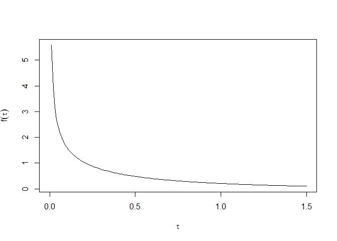

```r
tau=seq(0,1.5,0.01)
alpha=0.5
beta=1
priori=dgamma(tau,shape=alpha, scale=1/beta)
plot(tau,priori,type='l',xlab=expression(tau),ylab=expression(f(tau)))
```

- Gráfico da função de verossimilhança - vamos considerar a média conhecida

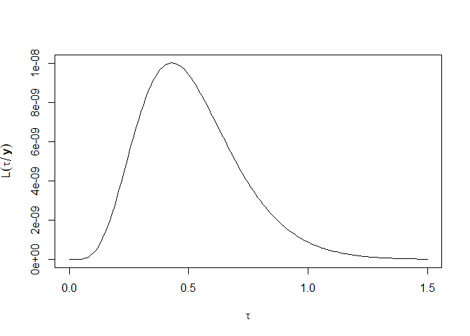

```r
mu=2
L_tau=(1/sqrt(2*pi))^n*tau^(n/2)*exp(-tau/2*sum((y-mu)^2))
plot(tau,L_tau,xlab=expression(tau),ylab=expression(L(tau /bold(y))),type='l')
```

- Posteriori

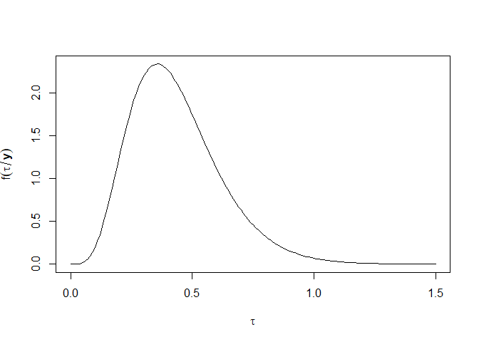

```r
posteriori=dgamma(tau,shape=alpha+n/2, scale=1/(beta+1/2*sum((y-mu)^2)))
plot(tau,posteriori,xlab=expression(tau),ylab=expression(f(tau /bold(y))),type='l')
```

## 2.5 Exercícios

- 1. Mostre que a família de distribuições Beta é conjugada em relação à binomial, geométrica e binomial negativa.
- 2. Para uma amostra aleatória $X_1,\dots,X_n$ tomada da distribuição $U(0,\theta)$, mostre que a família de distribuições de Pareto com parâmetros $a$ e $b$, cuja função de densidade é $f(\theta)=\frac{ab^a}{\theta^{a+1}}$, é conjugada à uniforme.
- 3. Suponha que o tempo, em minutos, para atendimento a clientes segue uma distribuição exponencial com parâmetro $\theta$ desconhecido. Com base na experiência anterior assume-se uma distribuição a priori Gamma com média $0.2$ e desvio-padrão $1$ para $\theta$. Se o tempo médio para atender uma amostra aleatória de $20$ clientes foi de $3.8$ minutos, determine a distribuição a posteriori de $\theta$.
- 4. Seja $X_1,\dots,X_n$ uma amostra aleatória da distribuição de Poisson com parâmetro $\theta$. Determine os parâmetros da priori conjugada de $\theta$ sabendo que $E(\theta)=4$ e o coeficiente de variação *a priori* é igual a $0.5$.
- 5. O número médio de defeitos por $100$ metros de uma fita magnética é desconhecido e denotado por $\theta$. Atribui-se uma distribuição a priori $\text{Gamma }(2,10)$ para $\theta$. Se um rolo de $1200$ metros desta fita foi inspecionado e encontrou-se $4$ defeitos, qual é a distribuição *a posteriori* de $\theta$?

## 2.6 Princípio da Verossimilhança

**Exemplo:** Suponha que desejamos estimar $\theta$, a probabilidade de observar cara (C) no lançamento de uma moeda e que, para um determinado experimento, observou-se:
$$\{C,\bar{C},\bar{C},C,C,\bar{C},\bar{C},\bar{C},\bar{C},C\}$$
Entre outras possibilidades, os dados acima podem ter sido gerados a partir dos seguintes experimentos:

- Seja $X$ o número de caras em $10$ lançamentos da moeda:
  $$X \sim \text{ Binomial }(10,\theta), \text{ e os resultados poderiam ser: } X = 0,1,2,\ldots,10.$$
- Seja $Y$ o número de lançamentos da moeda até a obtenção de $4$ caras:
  $$Y \sim \text{ Binomial Negativa }(4,\theta), \text{ e os resultados poderiam ser: } Y = 4,5,6,\ldots$$
- Considerando os resultados do experimento no modelo Binomial:

$$\begin{eqnarray*}
&&P(X = 4 \mid \theta) = \left(\begin{array}{l l}10\\4\end{array}\right) \theta^4 (1 - \theta)^{10-4}, \\
\end{eqnarray*}$$

de modo que a função de verossimilhança será: $L(\theta \mid \text{ x} ) \propto \theta^4 (1 - \theta)^6$;

- E no modelo Binomial Negativa:

$$\begin{eqnarray*}
&& P(Y = 10 \mid \theta) = \left(\begin{array}{l l}10-1\\4-1\end{array}\right) \theta^4 (1 -\theta)^{10-4},\\
&& \text{ de modo que a função de verossimilhança será: } L(\theta \mid \text{ y} ) \propto \theta^4 (1 - \theta)^6;
\end{eqnarray*}$$

### 2.6.2 *priori* Uniforme

É uma *priori* intuitiva porque todos os possíveis valores do parâmetro $\theta$ são igualmente prováveis:
$$f(\theta)\propto k,$$
com $\theta$ variando em um subconjunto da reta de modo que nenhum valor particular tem preferência (Bayes, 1763).

A *priori* uniforme, no entanto, apresenta algumas dificuldades:

- Se o intervalo de variação de $\theta$ for a reta real então a distribuição é imprópria:
  $$\int \limits_{-\infty}^{\infty} f(\theta )d\theta =\infty,$$
  mas este não chega a ser um impedimento para a escolha de *prioris*, como veremos mais adiante.
- Se $\phi =g(\theta )$ é uma reparametrização não linear monótona de $\theta$ então a *priori* para o parâmetro $\phi$ será:
  $$f(\phi)=f(\theta(\phi))\left\vert\frac{d\theta}{d\phi}\right\vert\propto \left\vert\frac{d\theta}{d\phi}\right\vert,$$
  e vemos pelo **Teorema de transformação de variáveis** que a *priori* para $\phi$ não é uniforme.

### 2.6.3 *priori* de Jeffreys

É uma *priori* construída a partir da **medida de informação esperada de Fisher**, proposta por Jeffreys (1961).

- é uma *priori* **imprópria**;
- é **invariante** a transformações $1$ a $1$.

**Definição: Medida de informação esperada de Fisher** Considere uma única observação $X$ com f.d.p. indexada pelo parâmetro $\theta$: $f(x \vert \theta)$. A medida de informação esperada de Fisher de $\theta$ através de $X$ é definida como
$$\displaystyle I(\theta)=E \left[-\frac{\partial^2\log f(x \vert \theta)}{\partial\theta^2}\right],$$
em que a esperança matemática é tomada em relação à distribuição amostral $f(x \vert \theta)$ (a esperança é com respeito a $X$ e não com respeito a $\theta$). - A informação esperada de Fisher $I(\theta)$ é uma **medida de informação global**.

Extendendo esta definição para uma amostra i.i.d. $X_1,X_2,\ldots,X_n$, temos: $f(\boldsymbol{x} \vert \theta)=\prod \limits_{i=1}^n f(x_i \vert \theta)$ e
$$\displaystyle I(\theta)=E \left[-\frac{\partial^2\log f(\boldsymbol{x} \vert \theta)}{\partial\theta^2}\right],$$
é a informação esperada de Fisher de $\theta$ através do vetor $\boldsymbol{x}$.

**Definição:** *priori* de Jeffreys A *priori* de Jeffreys é dada por:
$$\sqrt{I(\theta)}.$$

No caso multiparamétrico (mais de um parâmetro), a medida de Informação de Fisher é dada de forma matricial, então temos:
$$\sqrt{\left| \text{det}\left[I(\boldsymbol{\theta})\right]\right|}.$$

**Exemplo:** Sejam $X_1,\ldots,X_n \sim \text{Poisson} (\theta)$.

$$\begin{eqnarray*}
\log f(\boldsymbol{x} \vert \theta) &=&-n\theta + \sum_{i=1}^n x_i \log (\theta) - \log\left(\prod_{i=1}^n x_i!\right) \\
\frac{\partial \log f(\boldsymbol{x} \vert\theta)}{\partial\theta}&=&-n+\frac{\sum_{i=1}^n x_i}{\theta}\\
\frac{\partial^2 \log f(\boldsymbol{x} \vert \theta)}{\partial\theta^2}&=&-\frac{\sum_{i=1}^n x_i}{\theta^2}\\
I(\theta) &=& \frac{n}{\theta}\\
&\propto& \frac{1}{\theta}\\
\end{eqnarray*}$$

- A *priori* de Jeffreys para $\theta$ no modelo Poisson é $f(\theta)\propto\theta^{-1/2}$;
- Esta priori também pode ser obtida tomando-se a *priori* conjugada $\text{Gamma}(\alpha,\beta)$ com $\alpha=\frac{1}{2}$ e $\beta \rightarrow 0$. Note que o parâmetro $\beta$ é sempre positivo, por isso a noção de “tender a zero”. **Tarefa: verificar**;
- Em geral, quando o modelo admite *priori* conjugada, basta fixar um dos parâmetros da *priori* conjugada e o outro parâmetro “tender a zero”, resultando na *priori* de Jeffreys;
- A *priori* de Jeffreys não satisfaz o **princípio da verossimilhança**, pois a informação esperada de Fisher depende da distribuição amostral (o cálculo das esperanças matemáticas podem ser diferentes se os modelos forem diferentes como no exemplo modelos Binomial e Binomial-Negativa).
- A *priori* de Jeffreys apresenta algumas particularidades nos modelos de locação-escala, como veremos a seguir.

## 2.7 Modelos de locação-escala

**Modelo de Locação** $X$ tem um modelo de locação se existem uma função $g$ e uma quantidade $\mu$ tais que:
$$f(x \vert \mu)=g(x-\mu),$$
logo $\theta$ é o parâmetro de locação.

- A definição se extende para o caso multiparamétrico;
- **Exemplos:** distribuição normal com variância conhecida e distribuição normal multivariada com matriz de variância-covariância conhecida.
- **Propriedade:** A *priori* de Jeffreys para o parâmetro de locação $\mu$ é:
  $$f(\mu)\propto k,$$
  onde $k$ é uma constante.

**Modelo de Escala** $X$ tem um modelo de escala se existem uma função $g$ e uma quantidade $\sigma$ tais que:
$$f(x \vert \sigma)=\frac{1}{\sigma} g\left(\frac{x}{\sigma}\right),$$
logo $\sigma$ é o parâmetro de escala.

- **Exemplos:** Na distribuição $\text{Exp}(\theta)$ o parâmetro de escala é $\sigma=\frac{1}{\theta}$, e na distribuição $\text{N}(\mu,\sigma^2)$ com média conhecida o parâmetro de escala é $\sigma$;
- **Propriedade:** A *priori* de Jeffreys para o parâmetro de escala $\sigma$ é:
  $$f(\sigma) \propto \frac{1}{\sigma}.$$

**Definição: Modelo de Locação-escala** $X$ tem um modelo de locação-escala se existem uma função $g$ e as quantidades $\mu$ e $\sigma$ tais que
$$f(x\vert\mu,\sigma)=\frac{1}{\sigma}g\left(\frac{x-\mu}{\sigma}\right),$$
logo $\mu$ é o parâmetro de locação e $\sigma$ é o parâmetro de escala.

- **Exemplos:** Na distribuição $\text{N}(\mu,\sigma^2)$ o parâmetro de locação é $\mu$ e o parâmetro de escala é $\sigma$, e a distribuição de Cauchy também é um modelo de locação-escala.
- **Propriedade** A *priori* conjunta de Jeffreys para os parâmetros de locação $\mu$ e escala $\sigma$ é:
  $$f(\mu,\sigma)=f(\mu)f(\sigma) \propto \frac{1}{\sigma},$$
  onde nós assumimos independência (a *priori* conjunta é o produto das *prioris*).

**Exemplo:** Sejam $X_1,\dots,X_n \sim N(\mu,\sigma^2)$ com $\mu$ e $\sigma^2$ desconhecidos, temos:
$$f\left(x \vert \mu, \sigma^2 \right)=\frac{1}{\sigma} \left\{\frac{1}{\sqrt{2\pi}} \exp\left[-\frac{1}{2} \left(\frac{ x-\mu}{\sigma}\right)^2\right] \right\},$$
logo $\mu$ é o parâmetro de locação e $\sigma$ é o parâmetro de escala.

- A *priori* não informativa de Jeffreys para o vetor $(\mu,\sigma)$ é:
  $$f(\mu,\sigma)\propto\frac{1}{\sigma}$$
- Pela **propriedade da invariância**, a *priori* não informativa de Jeffreys para o vetor $(\mu,\sigma^2)$ é:
  $$f(\mu,\sigma^2)\propto\frac{1}{\sigma^2}$$

# 3 Unidade III - Inferência Bayesiana

## 3.1 Exemplo 3.1: Regressão linear simples

O problema envolve as variáveis $X$: a dose de um medicamento anti-alérgico em estudo, e $Y$: tempo de duração do efeito (alívio dos sintomas alérgicos). Abaixo temos a representação gráfica dos dados observados Pelo gráfico, nós concluímos que uma relação linear (reta) é satisfatória para os dados. Também iremos supor que $X$ é uma variável controlada pelo pesquisador (sem a presença de erros).

```r
x=c(3,3,4,5,6,6,7,8,8,9)
y=c(9,5,12,9,14,16,22,18,24,22)
a=cbind(x,y)
a
```

```
##       x  y
##  [1,] 3  9
##  [2,] 3  5
##  [3,] 4 12
##  [4,] 5  9
##  [5,] 6 14
##  [6,] 6 16
##  [7,] 7 22
##  [8,] 8 18
##  [9,] 8 24
## [10,] 9 22
```

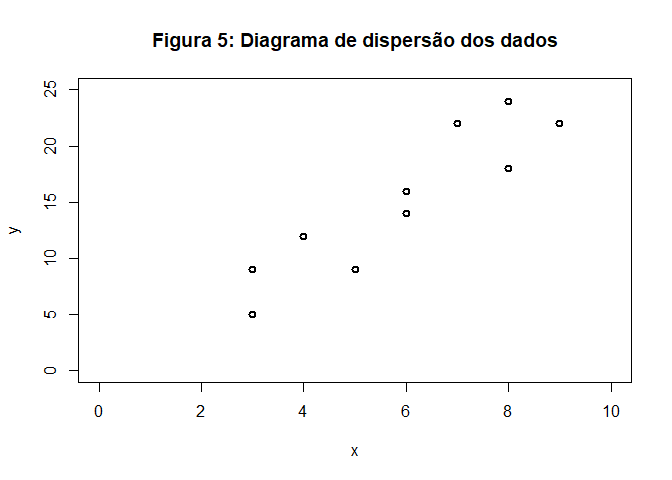

```r
plot(x,y,lwd=2,xlim=c(0,10),ylim=c(0,25),main="Figura 5: Diagrama de dispersão dos dados")
```

**Modelo Estatístico** O modelo estatístico será o modelo de regressão simples com erros i.i.d. normais:
$$y_i=\beta_0+\beta_1 x_i + \epsilon_i, i=1,\ldots,n,$$
onde $\beta_0$: intercepto da linha de regressão com o eixo $y$;
$\beta_1$: coeficiente de inclinação da reta: é o nº de unidades em $y$ que mudam para cada unidade da variável independente $x$.
$\epsilon_i$: erros aleatórios com distribuição normal: $\epsilon_i \sim N(0,\sigma^2)$.

**Estimadores de mínimos quadrados da regressão** Encontrar $\widehat{\beta_0}$ e $\widehat{\beta_1}$ que minimizam a soma de quadrados dos erros:  
$S(\beta_0,\beta_1)=\sum \limits_{i=1}^{n} \epsilon_i^2 = \sum \limits_{i=1}^{n} (y_i-\beta_0-\beta_1 x_i)^2$.  
Então temos as **equações normais:**

$$\frac{\partial S} {\partial \beta_0} =0 \text{ e } \frac{\partial S} {\partial \beta_1} =0.$$

A solução é dada por:

$$\begin{eqnarray*}
\widehat{\beta_1}&=&\frac{\sum \limits_{i=1}^{n} (x_i-\bar{x})(y_i-\bar{y})}{\sum \limits_{i=1}^{n} (x_i-\bar{x})^2}\\
\widehat{\beta_0}&=&\bar{y}-\widehat{\beta_1}\bar{x}.
\end{eqnarray*}$$

Com respeito a variância $\sigma_2$:
$$\widehat{\sigma_2}=\frac{SQR}{n-2},$$
ou seja, a estimativa da variância é igual à soma dos quadrados dos resíduos sobre o número graus de liberdade do modelo. Os intervalos de confiança e testes de hipóteses para $\beta_0$ e $\beta_1$ são baseados na distribuição t-student.

**Voltando ao R:**  
- Método dos mínimos quadrados: cálculo das estimativas passo a passo

```r
soma_xx=sum((x-mean(x))^2)
soma_xy=sum((x-mean(x))*(y-mean(y)))
beta1_hat=soma_xy/soma_xx
beta0_hat=mean(y)-beta1_hat*mean(x)
print(paste0("beta0_hat=",beta0_hat," & beta1_hat=",beta1_hat))
```

```
## [1] "beta0_hat=-1.07090464547677 & beta1_hat=2.74083129584352"
```

- Método dos mínimos quadrados: utilizando a função lm:linear model

```r
a=lm(y ~ x)
summary(a)
```

```
##
## Call:
## lm(formula = y ~ x)
##
## Residuals:
##     Min      1Q  Median      3Q     Max
## -3.6333 -2.0128 -0.3741  2.0428  3.8851
##
## Coefficients:
##             Estimate Std. Error t value Pr(>|t|)
## (Intercept)  -1.0709     2.7509  -0.389 0.707219
## x             2.7408     0.4411   6.214 0.000255 ***
## ---
## Signif. codes:  0 '***' 0.001 '**' 0.01 '*' 0.05 '.' 0.1 ' ' 1
##
## Residual standard error: 2.821 on 8 degrees of freedom
## Multiple R-squared:  0.8284, Adjusted R-squared:  0.8069
## F-statistic: 38.62 on 1 and 8 DF,  p-value: 0.0002555
```

# 4 Inferência Bayesiana no modelo de regressão linear simples

Assumimos as seguintes distribuições *a priori*:  
$\beta_0 \sim N(0,a_0^2)$ com $a_0$ conhecido $\beta_0 \sim N(0,a_1^2)$ com $a_1$ conhecido $\sigma_2 \sim IG(b,d)$ com $b$ e $d$ conhecidos Iremos assumir independência *a priori* entre os parâmetros.

- Função de verossimilhança:

$$\begin{eqnarray*}
L(\beta_0,\beta_1,\sigma^2)&=&\prod \limits_{i=1}^n \frac{1}{2 \pi \sigma^2} \exp\left[-\frac{1}{2\sigma^2}(y_i-\beta_0-\beta_1x_i)^2\right]\\
&=& (\sigma^2)^{-\frac{n}{2}} \exp\left[-\frac{1}{2\sigma^2}\sum \limits_{i=1}^n (y_i-\beta_0-\beta_1x_i)^2\right]
\end{eqnarray*}$$

- Distribuição *a posteriori* conjunta para $\beta_0$,$\beta_1$ e $\sigma^2$ é dada por:

$$\begin{eqnarray*}
f(\beta_0,\beta_1,\sigma^2 \mid \boldsymbol{x}, \boldsymbol{y}) &\propto& \exp\left[-\frac{\beta_0^2}{2a_0^2}\right] \exp\left[-\frac{\beta_1^2}{2a_1^2}\right] (\sigma^2)^{-(b+1)} \exp\left[-\frac{d}{\sigma^2}\right] (\sigma^2)^{-\frac{n}{2}}
\exp\left[-\frac{1}{2\sigma^2}\sum \limits_{i=1}^n (y_i-\beta_0-\beta_1x_i)^2\right]\\
&\propto& \exp\left[-\frac{\beta_0^2}{2a_0^2}\right] \exp\left[-\frac{\beta_1^2}{2a_1^2}\right] (\sigma^2)^{-(b+\frac{n}{2}+1)} \exp\left[-\frac{d}{\sigma^2}\right]
\exp\left[-\frac{1}{2\sigma^2}\sum \limits_{i=1}^n (y_i-\beta_0-\beta_1x_i)^2\right]
\end{eqnarray*}$$

- Distribuições *a posteriori* marginais - é necessário integrar com respeito aos outros parâmetros, respeitando os limites de integração:
  $\checkmark$ A conjunta de $\beta_0$ e $\beta_1$ é obtida da integração com respeito à variância $\sigma^2$:
  $$f(\beta_0,\beta_1 \mid \boldsymbol{x}, \boldsymbol{y}) = \int \limits _0^\infty f(\beta_0,\beta_1,\sigma^2 \mid \boldsymbol{x}, \boldsymbol{y}) d\sigma^2\\$$

$\checkmark$ A marginal de $\sigma^2$ é obtida da integração com respeito à $\beta_0$ e $\beta_1$:
$$\begin{equation*}
f(\sigma^2\mid \boldsymbol{x}, \boldsymbol{y}) = \int \limits _{-\infty}^\infty \int \limits _{-\infty}^\infty f(\beta_0,\beta_1,\sigma^2 \mid \boldsymbol{x}, \boldsymbol{y}) d\beta_0 d\beta_1
\end{equation*}$$

$\checkmark$ A marginal de $\beta_0$ é obtida da integração com respeito à $\beta_1$:
$$f(\beta_0\mid \boldsymbol{x}, \boldsymbol{y}) = \int \limits _{-\infty}^\infty f(\beta_0,\beta_1 \mid \boldsymbol{x}, \boldsymbol{y}) d\beta_1$$

$\checkmark$ A marginal de $\beta_1$ é obtida da integração com respeito à $\beta_0$:
$$f(\beta_1\mid \boldsymbol{x}, \boldsymbol{y}) = \int \limits _{-\infty}^\infty f(\beta_0,\beta_1 \mid \boldsymbol{x}, \boldsymbol{y}) d\beta_0$$

$\checkmark$ A conjunta de $\beta_0$ e $\beta_1$ pode ser obtida analiticamente:

$$\begin{eqnarray*}
f(\beta_0,\beta_1 \mid \boldsymbol{x}, \boldsymbol{y}) &\propto& \exp\left[-\frac{\beta_0^2}{2a_0^2}\right] \exp\left[-\frac{\beta_1^2}{2a_1^2}\right] \int \limits _{0}^\infty (\sigma^2)^{-(b+\frac{n}{2}+1)} \exp\left[-\frac{1}{\sigma^2} \left(d + \frac{1}{2}\sum \limits_{i=1}^n (y_i-\beta_0-\beta_1x_i)^2\right)\right]d\sigma^2\\
&\propto& \exp\left[-\frac{\beta_0^2}{2a_0^2}\right] \exp\left[-\frac{\beta_1^2}{2a_1^2}\right] \left[d + \frac{1}{2}\sum \limits_{i=1}^n (y_i-\beta_0-\beta_1x_i)^2\right]^{-\left(b+\frac{n}{2}\right)}.
\end{eqnarray*}$$

**Tarefa:** Provar este resultado. Dica: envolve a integral da distribuição  
Gamma Invertida $\left(b+\frac{n}{2},d+\frac{1}{2}\sum \limits_{i=1}^n (y_i - \beta_0 -\beta_1 x_i)^2\right)$ e o fato de que a integral de uma função de densidade sempre é igual a 1.  
Observe que mesmo tendo obtido a integral, ela não tem forma conhecida - não conseguimos identificar esta na tábua de distribuições com suporte de $-\infty$ a $\infty$.

Já as outras marginais não têm forma fechada - não são obtidas analiticamente - integrais analíticas não são possíveis.

$$\begin{eqnarray*}
&&f(\sigma^2 \mid \beta_0, \beta_1, \boldsymbol{x}, \boldsymbol{y}) \propto (\sigma^2)^ {-(b+\frac{n}{2}+1)} \exp \left[-\frac{1}{\sigma^2}\left(d+\frac{1}{2}\sum \limits_{i=1}^n (y_i - \beta_0 -\beta_1 x_i)^2\right) \right],\\
\text{ou seja, } &&\sigma^2 \mid \beta_0, \beta_1, \boldsymbol{x}, \boldsymbol{y} \sim IG \left(b+\frac{n}{2},d+\frac{1}{2}\sum \limits_{i=1}^n (y_i - \beta_0 -\beta_1 x_i)^2\right).
\end{eqnarray*}$$

a idéia de condicional nos diz que $\beta_0$ e $\beta_1$ são tratadas como constantes com respeito a $\sigma^2$.

$\checkmark$ A condicional de $\beta_0$ dado $\beta_1$, $\sigma^2$ e os dados:

$$\begin{eqnarray*}
&&f(\beta_0 \mid \beta_1, \sigma^2, \boldsymbol{x}, \boldsymbol{y}) \propto \exp\left[-\frac{\beta_0^2}{2a_0^2}\right]
\exp\left[-\frac{1}{2\sigma^2}\sum \limits_{i=1}^n (y_i-\beta_0-\beta_1x_i)^2\right]\\
&& \textbf{ Ideia: }\text{expandir os termos e identificar uma distribuição normal! Tome } \mu_i^{(1)} = y_i - \beta_1 x_i\\
&&\propto \exp\left[-\frac{\beta_0^2}{2a_0^2}\right]
\exp\left[-\frac{1}{2\sigma^2}\sum \limits_{i=1}^n (\beta_0-\mu_i^{(1)})^2\right] \\
&&\propto \exp\left[-\frac{\beta_0^2}{2a_0^2}\right]
\exp\left[-\frac{1}{2\sigma^2} \left(n \beta_0^2 + 2\beta_0 \sum \limits_{i=1}^n \mu_i^{(1)} + \sum \limits_{i=1}^n \mu_i^{{(1)}^2}\right)\right] \\
&&\propto \exp\left[-\frac{\beta_0^2}{2} \left(\frac{1}{a_0^2}+\frac{n}{\sigma^2}\right)+\frac{\beta_0 \sum \limits_{i=1}^n \mu_i^{(1)} }{\sigma^2}\right], \text{ o termo } \sum \limits_{i=1}^n \mu_i^{{(1)}^2} \text{ "caiu" pois é constante com respeito a } \beta_0\\
&& \propto \exp\left[-\frac{1}{2\left(\frac{1}{a_0^2}+\frac{n}{\sigma^2}\right)^{-1}} \left(\beta_0^2-\frac{2\beta_0 \sum \limits_{i=1}^n \mu_i^{(1)} }{\sigma^2 \left(\frac{1}{a_0^2}+\frac{n}{\sigma^2}\right)}\right)\right].
\text{ Mas } \left(\frac{1}{a_0^2}+\frac{n}{\sigma^2}\right)^{-1} = \left(\frac{\sigma^2+a_0^2n}{a_0^2 \sigma^2}\right)^{-1}=
\left(\frac{a_0^2 \sigma^2}{\sigma^2+a_0^2n}\right)\\
&& \propto \exp\left[-\frac{1}{2\left(\frac{a_0^2 \sigma^2}{\sigma^2+a_0^2n}\right)} \left(\beta_0^2-\frac{2\beta_0 \sum \limits_{i=1}^n \mu_i^{(1)} }{\sigma^2 \left(\frac{a_0^2 \sigma^2}{\sigma^2+a_0^2n}\right)}\right)\right], \text{ e simplificando um pouco mais: }\\
&& \propto \exp\left[-\frac{1}{2\left(\frac{a_0^2 \sigma^2}{\sigma^2+a_0^2n}\right)} \left(\beta_0^2-\frac{2\beta_0 a_0^2 \sum \limits_{i=1}^n \mu_i^{(1)} }{ \sigma^2+a_0^2n}\right)\right] \text{ e completando quadrados: }\\
&& \propto \exp\left[-\frac{1}{2\left(\frac{a_0^2 \sigma^2}{\sigma^2+a_0^2n}\right)} \left(\beta_0^2-\frac{2\beta_0 a_0^2 \sum \limits_{i=1}^n \mu_i^{(1)} }{ \sigma^2+a_0^2n} + \left(\frac{ a_0^2 \sum \limits_{i=1}^n \mu_i^{(1)} }{ \sigma^2+a_0^2n}\right)^2 \right)\right]\\
&& \propto \exp\left[-\frac{1}{2\left(\frac{a_0^2 \sigma^2}{\sigma^2+a_0^2n}\right)} \left(\beta_0-\frac{ a_0^2 \sum \limits_{i=1}^n \mu_i^{(1)} }{ \sigma^2+a_0^2n}\right)^2\right]\\
&& \text{ou seja, } \beta_0 \mid \beta_1, \sigma^2, \boldsymbol{x}, \boldsymbol{y} \sim N\left(\frac{ a_0^2 \sum \limits_{i=1}^n \mu_i^{(1)}}{ \sigma^2+a_0^2n},\frac{a_0^2 \sigma^2}{\sigma^2+a_0^2n}\right)
\end{eqnarray*}$$

$\checkmark$ Por fim, a condicional de $\sigma^2$ dado $\beta_1$, $\beta_0$ e os dados:

$$\begin{eqnarray*}
f(\sigma^2 \mid \beta_0,\beta_1,\boldsymbol{x}, \boldsymbol{y}) &\propto& (\sigma^2)^{-(b+\frac{n}{2}+1)} \exp\left[-\frac{d}{\sigma^2}\right]
\exp\left[-\frac{1}{2\sigma^2}\sum \limits_{i=1}^n (y_i-\beta_0-\beta_1x_i)^2\right]\\
&& \text{ou seja, } \sigma^2 \mid \beta_0,\beta_1,\boldsymbol{x}, \boldsymbol{y} \sim \text{ IG } \left(b+\frac{n}{2},d+\frac{1}{2}\sum \limits_{i=1}^n (y_i - \beta_0 -\beta_1 x_i)^2\right)
\end{eqnarray*}$$

**Aplicação da Metodologia**

$\checkmark$ Atribuir *prioris* não informativas para $\beta_0$ e $\beta_1$: Normais com média igual a zero e variância grande, por exemplo $10^6$.  
$\checkmark$ Atribuir *prioris* não informativas para $\sigma^2$. A distribuição $IG (0.001,0.001)$ é não informativa, e é muito próxima à *priori* de Jeffreys para o modelo normal com média e variância desconhecidos. **Tarefa: Verificar!** $\checkmark$ Utilizar o algoritmo de Gibbs. Veja descrição em sala com aplicação no R e Winbugs.